# Applied_Class08_Factor_Analysis

# Working with the Maximising, Satisfising and Happiness responses from week 1 :)

*How to deal with correlated variables*

# I. Install packages and load data

```r
#install libraries
pacman::p_load(tidyverse, psych, fmsb, GPArotation)
```

## Questions:

1. Whenever I’m faced with a choice, I try to imagine what all the other possibilities are, even ones that aren’t present at the moment.
2. No matter how satisfied I am with my job, it’s only right for me to be on the lookout for better opportunities
3. When I am in the car listening to the radio, I often check other stations to see if something better is playing, even if I am relatively satisfied with what I’m listening to.
4. When I watch TV, I channel surf, often scanning through the available options even while attempt- ing to watch one program.
5. I treat relationships like clothing: I expect to try a lot on before finding the perfect fit.
6. I often find it difficult to shop for a gift for a friend.
7. Seeing a film is really difficult. I’m always struggling to pick the best one.
8. When shopping, I have a hard time finding cloth-ing that I really love.
9. I’m a big fan of lists that attempt to rank things (the best movies, the best singers, the best athletes, the best novels, etc.).
10. I find that writing is very difficult, even if it’s just writing a letter to a friend, because it’s so hard to word things just right. I often do several drafts of even simple things.
11. No matter what I do, I have the highest standards for myself.
12. I never settle for second best.
13. I often fantasize about living in ways that are quitedifferent from my actual life.
14. Once I make a decision, I don’t look back.
15. Whenever I make a choice, I’m curious about what would have happened if I had chosen differently.
16. If I make a choice and it turns out well, I still feel like something of a failure if I find out that anotherchoice would have turned out better.
17. Whenever I make a choice, I try to get information about how the other alternatives turned out.
18. When I think about how I’m doing in life, I often assess opportunities I have passed up.
19. In general, I consider myself (1= not a very happy person, 7 = a very happy person).
20. Compared to most of my peers, I consider myself: (1= less happy, 7 = more happy).
21. Some people are generally very happy. They enjoy life regardless of what is going on, getting the most out of everything. To what extent does this characterization describe you? (1= not at all, 7 = a great deal).
22. Some people are generally not very happy. Although they are not depressed, they never seem as happy as they might be. To what extend does this characterization describe you? (1= not at all, 7 = a great deal).

# 1. Clean the data

```r
# load data
df_max_full <- read_csv("maximising_responses.csv")
#change header names
names(df_max_full) <- c("time","year","gender",1:22)

# only choose the responses
df_max_filtered <- df_max_full[,4:25]
```

# 2. Make Correlation Matrix

**2.a: Do you see any patterns emerging, do the variables seem correlated?**

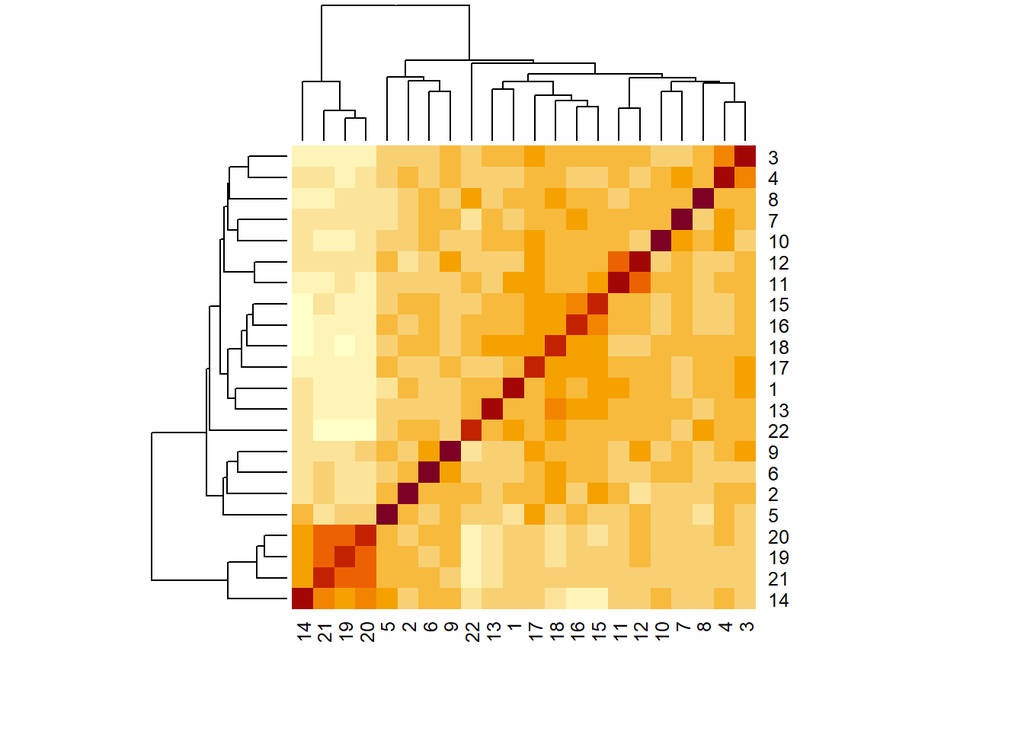

```r
#Create correlation matrix (save as variable)
df_max_cor <- cor(df_max_filtered)
heatmap(df_max_cor)
```

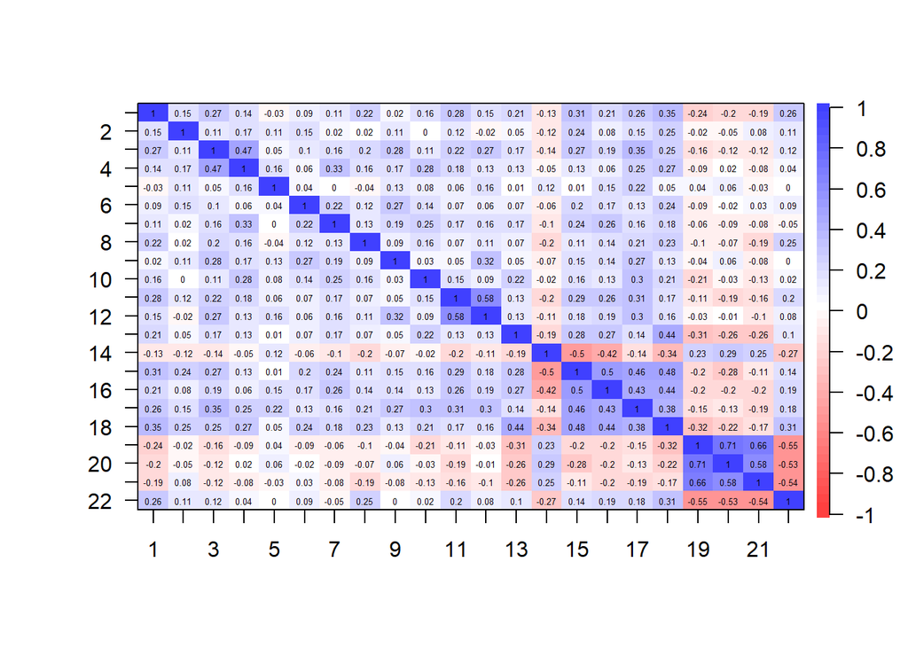

```r
corPlot(df_max_cor)
```

# 3 Find number of factors

**3.a: Interpret the screeplot and conclude how many factors the analysis suggest you to use**

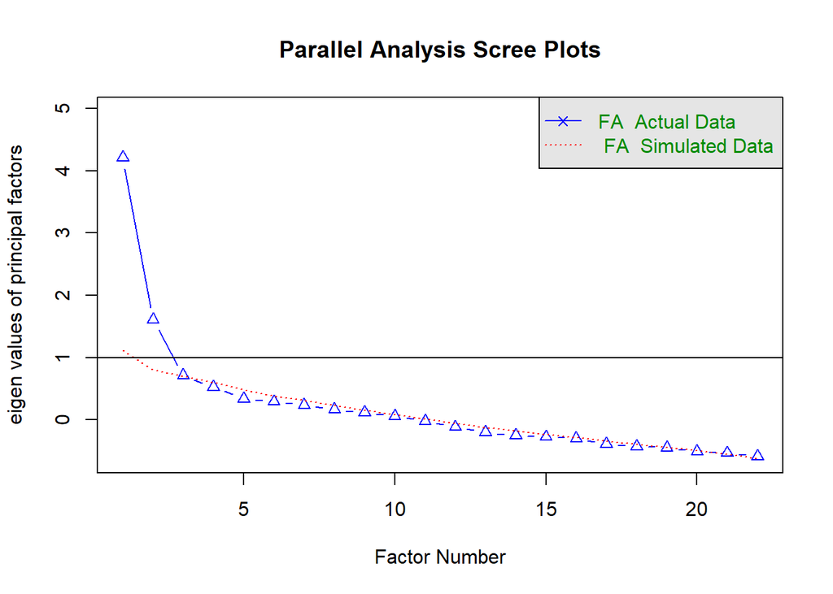

```
## Parallel analysis suggests that the number of factors =  3  and the number of components =  NA
```

```r
# find number of factors
fa.parallel(df_max_cor,fa="fa")
```

```r
# only 2, mabye 3 factors is good enough, as they are close to 1 or above
```

# 4. Conduct Analysis

```r
#4. conduct FA analysis
fa_max_2 <- fa(df_max_filtered, 2)
fa_max_3 <- fa(df_max_filtered, 3)
fa_max_2
```

```
## Factor Analysis using method =  minres
## Call: fa(r = df_max_filtered, nfactors = 2)
## Standardized loadings (pattern matrix) based upon correlation matrix
##      MR1   MR2    h2   u2 com
## 1   0.37 -0.17 0.207 0.79 1.4
## 2   0.27  0.06 0.066 0.93 1.1
## 3   0.53  0.05 0.262 0.74 1.0
## 4   0.48  0.14 0.202 0.80 1.2
## 5   0.21  0.14 0.045 0.96 1.8
## 6   0.32  0.07 0.090 0.91 1.1
## 7   0.42  0.10 0.158 0.84 1.1
## 8   0.27 -0.09 0.099 0.90 1.2
## 9   0.40  0.17 0.144 0.86 1.4
## 10  0.34  0.00 0.115 0.89 1.0
## 11  0.46 -0.03 0.219 0.78 1.0
## 12  0.48  0.12 0.203 0.80 1.1
## 13  0.31 -0.22 0.189 0.81 1.8
## 14 -0.30  0.27 0.219 0.78 2.0
## 15  0.61 -0.08 0.416 0.58 1.0
## 16  0.54 -0.10 0.341 0.66 1.1
## 17  0.67  0.05 0.424 0.58 1.0
## 18  0.58 -0.16 0.431 0.57 1.2
## 19 -0.02  0.83 0.704 0.30 1.0
## 20  0.04  0.82 0.656 0.34 1.0
## 21 -0.02  0.72 0.531 0.47 1.0
## 22  0.05 -0.65 0.446 0.55 1.0
##
##                        MR1  MR2
## SS loadings           3.51 2.66
## Proportion Var        0.16 0.12
## Cumulative Var        0.16 0.28
## Proportion Explained  0.57 0.43
## Cumulative Proportion 0.57 1.00
##
##  With factor correlations of
##       MR1   MR2
## MR1  1.00 -0.35
## MR2 -0.35  1.00
##
## Mean item complexity =  1.2
## Test of the hypothesis that 2 factors are sufficient.
##
## The degrees of freedom for the null model are  231  and the objective function was  6.96 with Chi Square of  806.23
## The degrees of freedom for the model are 188  and the objective function was  2.49
##
## The root mean square of the residuals (RMSR) is  0.07
## The df corrected root mean square of the residuals is  0.08
##
## The harmonic number of observations is  125 with the empirical chi square  301.17  with prob <  3e-07
## The total number of observations was  125  with Likelihood Chi Square =  284.61  with prob <  6.8e-06
##
## Tucker Lewis Index of factoring reliability =  0.79
## RMSEA index =  0.064  and the 90 % confidence intervals are  0.049 0.079
## BIC =  -623.12
## Fit based upon off diagonal values = 0.89
## Measures of factor score adequacy
##                                                    MR1  MR2
## Correlation of (regression) scores with factors   0.91 0.93
## Multiple R square of scores with factors          0.84 0.87
## Minimum correlation of possible factor scores     0.67 0.74
```

```r
fa_max_3
```

```
## Factor Analysis using method =  minres
## Call: fa(r = df_max_filtered, nfactors = 3)
## Standardized loadings (pattern matrix) based upon correlation matrix
##      MR2   MR1   MR3    h2   u2 com
## 1  -0.18  0.22  0.21 0.203 0.80 2.9
## 2   0.09  0.27  0.07 0.081 0.92 1.4
## 3  -0.06  0.05  0.53 0.328 0.67 1.0
## 4   0.00 -0.07  0.59 0.319 0.68 1.0
## 5   0.07 -0.06  0.28 0.070 0.93 1.2
## 6   0.06  0.21  0.16 0.090 0.91 2.1
## 7   0.04  0.15  0.33 0.161 0.84 1.4
## 8  -0.13  0.09  0.21 0.103 0.90 2.1
## 9   0.08  0.04  0.40 0.169 0.83 1.1
## 10 -0.08  0.02  0.35 0.143 0.86 1.1
## 11 -0.09  0.15  0.37 0.230 0.77 1.5
## 12  0.01  0.02  0.50 0.258 0.74 1.0
## 13 -0.20  0.26  0.11 0.190 0.81 2.3
## 14  0.15 -0.58  0.15 0.368 0.63 1.3
## 15  0.06  0.83  0.02 0.671 0.33 1.0
## 16 -0.03  0.60  0.10 0.425 0.57 1.1
## 17 -0.02  0.29  0.47 0.422 0.58 1.7
## 18 -0.12  0.55  0.18 0.470 0.53 1.3
## 19  0.86  0.01 -0.02 0.734 0.27 1.0
## 20  0.76 -0.13  0.14 0.640 0.36 1.1
## 21  0.81  0.12 -0.11 0.626 0.37 1.1
## 22 -0.64  0.07  0.00 0.446 0.55 1.0
##
##                        MR2  MR1  MR3
## SS loadings           2.65 2.36 2.13
## Proportion Var        0.12 0.11 0.10
## Cumulative Var        0.12 0.23 0.32
## Proportion Explained  0.37 0.33 0.30
## Cumulative Proportion 0.37 0.70 1.00
##
##  With factor correlations of
##       MR2   MR1   MR3
## MR2  1.00 -0.34 -0.16
## MR1 -0.34  1.00  0.39
## MR3 -0.16  0.39  1.00
##
## Mean item complexity =  1.4
## Test of the hypothesis that 3 factors are sufficient.
##
## The degrees of freedom for the null model are  231  and the objective function was  6.96 with Chi Square of  806.23
## The degrees of freedom for the model are 168  and the objective function was  1.99
##
## The root mean square of the residuals (RMSR) is  0.06
## The df corrected root mean square of the residuals is  0.07
##
## The harmonic number of observations is  125 with the empirical chi square  216  with prob <  0.0074
## The total number of observations was  125  with Likelihood Chi Square =  226.61  with prob <  0.0017
##
## Tucker Lewis Index of factoring reliability =  0.856
## RMSEA index =  0.052  and the 90 % confidence intervals are  0.033 0.07
## BIC =  -584.55
## Fit based upon off diagonal values = 0.92
## Measures of factor score adequacy
##                                                    MR2  MR1  MR3
## Correlation of (regression) scores with factors   0.94 0.91 0.86
## Multiple R square of scores with factors          0.88 0.83 0.75
## Minimum correlation of possible factor scores     0.76 0.66 0.49
```

# 5. Inspect Loadings

**5.a: Which questions are determining what factors?** **5.b: By inspecting the loadings, interpret the factors**

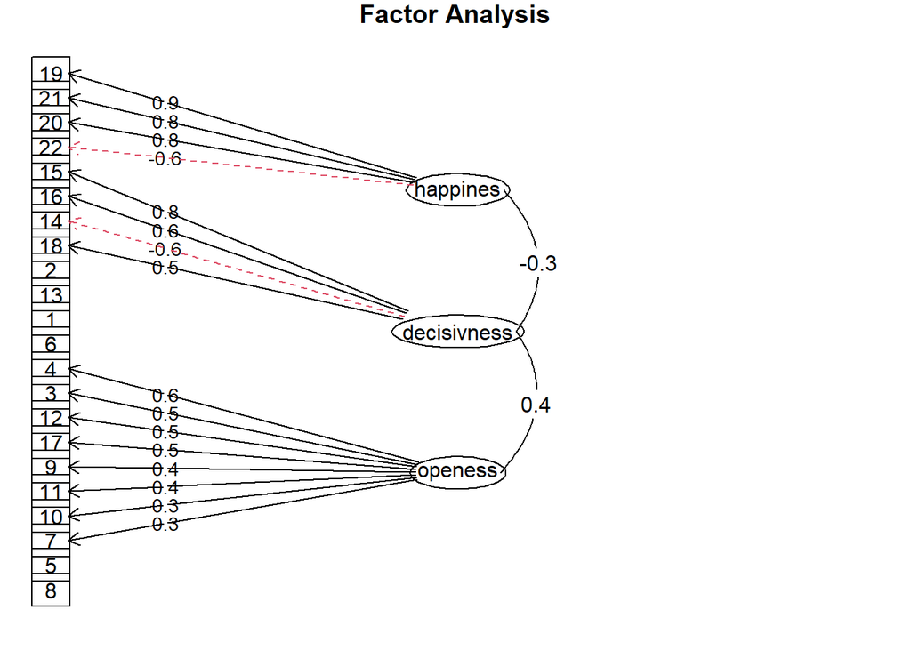

```r
#inspect loadings manually
colnames(fa_max_3$loadings) <- c("happines","decisivness", "openess")
fa.diagram(fa_max_3)
```

```r
print(fa_max_3$loadings, cutoff = 0.5)
```

```
##
## Loadings:
##    happines decisivness openess
## 1
## 2
## 3                        0.535
## 4                        0.588
## 5
## 6
## 7
## 8
## 9
## 10
## 11
## 12                       0.500
## 13
## 14          -0.583
## 15           0.830
## 16           0.598
## 17
## 18           0.547
## 19  0.856
## 20  0.764
## 21  0.806
## 22 -0.642
##
##                happines decisivness openess
## SS loadings       2.553       2.104   1.941
## Proportion Var    0.116       0.096   0.088
## Cumulative Var    0.116       0.212   0.300
```

# 6. Evaluate model

**6.a: How much variance does each factor explain?** **6.b: Try to change some parameters in your analysis (see ?fa() for help) and see how the model changes.**

The happiness and decisivness factors seem to fit well. The openess factor is a bit more up for interpritation, and a clarification of questions or larger sample size might be necessarry for a clear result of factors.